# Text Mining. Log-likelihood

Arina Astapenkova

```r
library(readxl)
library(tidytext)
library(stopwords)
library(dplyr)
```

```r
library(ggplot2)
library(wordcloud)
#install.packages("tm")
library(tm)
library(caret)
library(quanteda)
library(stringr)
#library(cleanNLP)
```

### Наши данные: ПостНаука

```r
# Загружаем данные
text_df <- read_excel("text_PN_lem.xlsx")

text_df <- text_df[,c(1,3,4,10)]

text.female <- text_df %>%
    filter(sex == "Female")
text.male <- text_df %>%
    filter(sex == "Male")

rm(text_df)
```

### Готовим данные для Female

```r
pn.long_female <- text.female %>%
    unnest_tokens(word, text.lem) %>%
    filter(! word %in% tm::stopwords("ru")) %>%
    filter(! word %in% c("это", "который")) %>%
    filter(! str_detect(word, "[0-9]+"))

pn.dtm_female <- pn.long_female %>%
    dplyr::count(line, word)

names(pn.dtm_female)
```

```
## [1] "line" "word" "n"
```

**Задание:** Почистите данные от лишних (стопслов) и подготовьте данные для Male и запишите ее как “pn.long_male” + создайте матрицу pn.dtm_male.

### Готовим данные для Male

```r
pn.long_male <- text.male %>%
  unnest_tokens(word, text.lem) %>%
  filter(!word %in% tm::stopwords("ru")) %>%
  filter(!word %in% c("это", "который")) %>%
  filter(!str_detect(word, "[0-9]+"))

pn.dtm_male <- pn.long_male %>%
  dplyr::count(line, word)

names(pn.dtm_male); head(pn.long_male)
```

```
## [1] "line" "word" "n"
```

```
## # A tibble: 6 × 4
##    line sex   prof    word
##   <dbl> <chr> <chr>   <chr>
## 1     1 Male  Историк почему
## 2     1 Male  Историк эсхатологический
## 3     1 Male  Историк ожидание
## 4     1 Male  Историк проходить
## 5     1 Male  Историк лейтмотив
## 6     1 Male  Историк весь
```

Соединяем предыдущие талицы в одину базу и оставляем слова, которые встречаются либо у женщин, либо у мужчин более 10 раз. Если хотим оставить слова, которые встречаются в обоих базах более 10 раз, заменяем “|” на “&”

```r
sex.lemmas.or <- bind_rows(pn.long_female, pn.long_male) %>%
    count(word, sex) %>%
    tidyr::spread(sex, n, fill = 0) %>%
    filter(Female > 10 | Male > 10)

sex.lemmas.and <- bind_rows(pn.long_female, pn.long_male) %>%
    count(word, sex) %>%
    tidyr::spread(sex, n, fill = 0) %>%
    filter(Female > 10 & Male > 10)
```

**Задание:** Выберите схему фильтрации и присвойте результат “sex.lemmas”.

```r
# выбрала схему фильтрации sex.lemmas.and
sex.lemmas <- sex.lemmas.and
```

# Посмотрим на распределение слов между мужчинами и женщинами

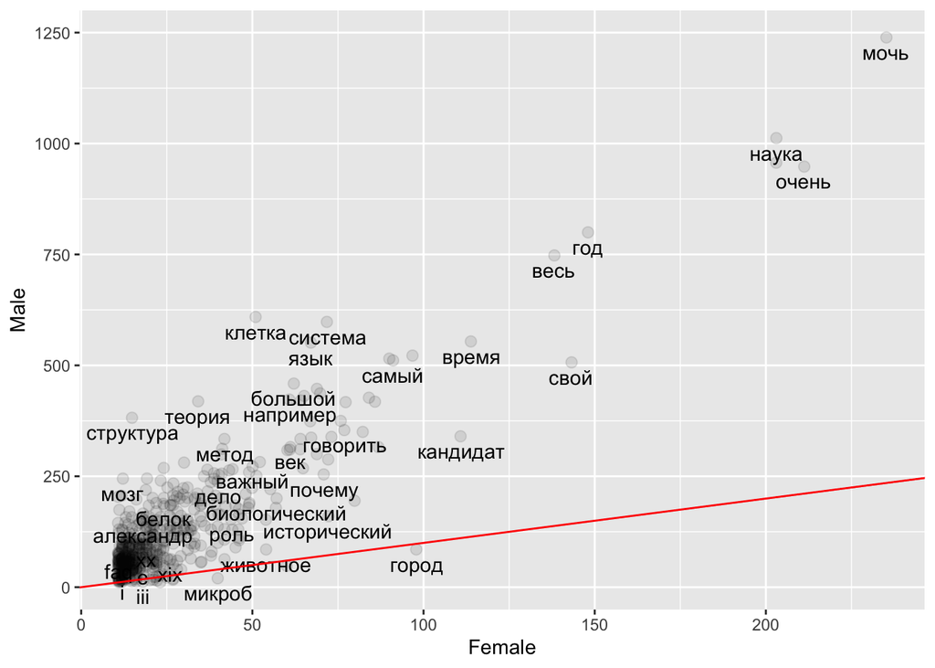

```r
library(scales)

ggplot(sex.lemmas, aes(Female, Male)) +
  geom_jitter(alpha = 0.1, size = 2.5, width = 0.25, height = 0.25) +
  geom_text(aes(label = word), check_overlap = TRUE, vjust = 1.5) +
  geom_abline(color = "red")
```

```r
# график показывает, что мужчины склонны больше к технической лексике, а женщины к социально-гуманитарной.
```

**Вопрос:** Подумайте, как построить более читабельный график?

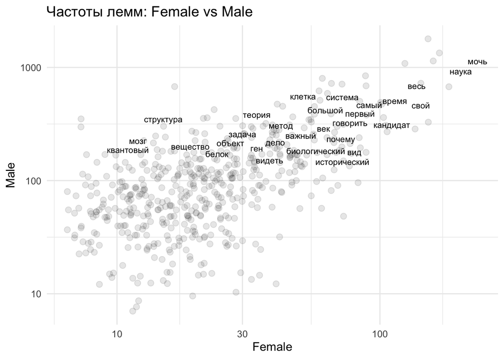

```r
r <- sum(sex.lemmas$Male, na.rm = TRUE) / sum(sex.lemmas$Female, na.rm = TRUE)

ggplot(sex.lemmas, aes(Female, Male)) +
  geom_jitter(alpha = 0.1, size = 2.5, width = 0.25, height = 0.25) +
  geom_text(
    data = subset(sex.lemmas, Female + Male >= 200),
    aes(label = word),
    check_overlap = TRUE, vjust = 1.2, size = 3
  ) +
  geom_abline(slope = r, intercept = 0, color = "yellow") +
  scale_x_log10() +
  scale_y_log10() +
  labs(
    x = "Female", y = "Male",
    title = "Частоты лемм: Female vs Male"
  ) +
  theme_minimal(base_size = 12)
```

# Log-likelihood (G^2)

```r
### Создаем функцию для рассчета логарифмической вероятности (log-likelihood: G-squared)

g2 = function(a, b) {
  c = sum(a)
  d = sum(b)
  E1 = c * ((a + b) / (c + d))
  E2 = d * ((a + b) / (c + d))
  return(2*((a*log(a/E1+1e-7)) + (b*log(b/E2+1e-7))))
}
```

# Давайте разберемся с формулой и разберем пример на доске!

Теперь мы можем вычислить log-likelihood для каждого слова

```r
sex.g2 <- sex.lemmas %>%
    mutate(g2=g2(Female, Male)) %>%
    arrange(desc(g2)) %>%
    mutate(g2 = round(g2, 2))
```

## Effect size. Log Ratio

Дополним наши расчеты вероятности правдоподобия размером эффекта. Это позволит количественно определить, насколько велика разница в относительной частотности слов.

Мы будем использовать самую простую меру размера эффекта: Log odds ratio (Отношение шансов) Смотрите детали тут: [Text mining with R book](https://www.tidytextmining.com/twitter.html#comparing-word-usage)).

```r
# Создаем функцию расчета Log odds ratio

logratio <- function(a, b) {
    return(log2((a/sum(a)/(b/sum(b)))))
}
```

```r
# Рассчитываем Log Ratio

sex.lr <- sex.g2 %>%
  mutate(
    logratio = logratio(Female, Male),
    p = 1 - pchisq(g2, df = 1),
    p_adj = p.adjust(p, method = "BH")
  )
proper_names <- c("наталья","елена","татьяна","светлана","алексей","сергей","михаил") #убираем имена, чтобы работать именно со словами
sex.lr <- sex.lr %>% filter(!word %in% proper_names)
```

# Слова, используемые мужчинами и женщинами

```r
sex.lr %>%
    arrange(abs(logratio))
```

```
## # A tibble: 513 × 7
##    word         Female  Male    g2 logratio     p p_adj
##    <chr>         <dbl> <dbl> <dbl>    <dbl> <dbl> <dbl>
##  1 ничто            17    81     0  0.00103     1     1
##  2 значение         28   134     0 -0.00531     1     1
##  3 просто           39   187     0 -0.00807     1     1
##  4 рамка            19    90     0  0.00949     1     1
##  5 народ            15    71     0  0.0106      1     1
##  6 около            15    71     0  0.0106      1     1
##  7 плохой           11    52     0  0.0124      1     1
##  8 человеческий     21   101     0 -0.0125      1     1
##  9 лежать           11    53     0 -0.0151      1     1
## 10 различие         11    53     0 -0.0151      1     1
## # ℹ 503 more rows
```

# Наиболее типичные (значимые) слова для мужчин и женщин

```r
sex.lr %>%
    filter(Female > 0 & Male > 0) %>%
    group_by(logratio < 0) %>%
    top_n(15, abs(logratio)) %>%
    ungroup()
```

```
## # A tibble: 30 × 8
##    word          Female  Male    g2 logratio        p    p_adj `logratio < 0`
##    <chr>          <dbl> <dbl> <dbl>    <dbl>    <dbl>    <dbl> <lgl>
##  1 город             98    85 123.      2.46 0        0        FALSE
##  2 микроорганизм     60    48  80.2     2.58 0        0        FALSE
##  3 микроб            40    20  71.4     3.25 0        0        FALSE
##  4 структура         15   382  70.3    -2.42 0        0        TRUE
##  5 клетка            51   609  51.5    -1.32 7.09e-13 7.27e-11 TRUE
##  6 стратегия         27    17  42.4     2.92 7.44e-11 6.36e- 9 FALSE
##  7 кино              23    11  42.0     3.32 9.17e-11 6.72e- 9 FALSE
##  8 конфликт          27    19  39.5     2.76 3.30e-10 2.11e- 8 FALSE
##  9 мозг              12   245  38.4    -2.10 5.82e-10 3.32e- 8 TRUE
## 10 теория            34   419  37.2    -1.37 1.04e- 9 5.36e- 8 TRUE
## # ℹ 20 more rows
```

### Нарисуем график:

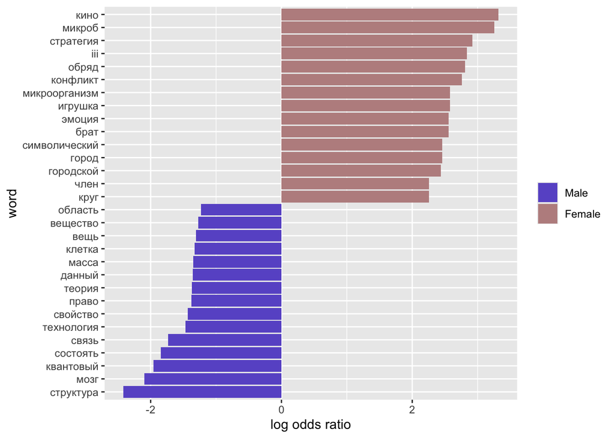

```r
sex.lr %>%
  filter(Female > 0 & Male > 0) %>%
  group_by(logratio < 0) %>%
  top_n(15, abs(logratio)) %>%
  ungroup() %>%
  mutate(word = reorder(word, logratio)) %>%
  ggplot(aes(word, logratio, fill = logratio > 0)) +
  geom_col(show.legend = TRUE) +
  coord_flip() +
  ylab("log odds ratio") +
  scale_fill_manual(
    values = c("FALSE" = "#6A5ACD",
               "TRUE"  = "#BC8F8F"),
    labels = c("FALSE" = "Male", "TRUE" = "Female"),
    name = NULL
  )
```

**Задание:** Посмотрите, в каком контексте употребляются значимые слова, проинтерпретируйте некоторые результаты (напишите текстом).

```r
get_snippets <- function(df, lemma, n = 8, pad = 45) {
  rx <- regex(paste0("(.{0,", pad, "})\\b", lemma, "\\b(.{0,", pad, "})"), ignore_case = TRUE)
  df %>%
    filter(str_detect(text.lem, rx)) %>%
    transmute(snippet = str_replace_all(str_extract(text.lem, rx),
                                        "\\s+", " ")) %>%
    distinct() %>%
    head(n)
}
get_snippets
```

```
## function (df, lemma, n = 8, pad = 45)
## {
##     rx <- regex(paste0("(.{0,", pad, "})\\b", lemma, "\\b(.{0,",
##         pad, "})"), ignore_case = TRUE)
##     df %>% filter(str_detect(text.lem, rx)) %>% transmute(snippet = str_replace_all(str_extract(text.lem,
##         rx), "\\s+", " ")) %>% distinct() %>% head(n)
## }
```

```r
# примеры
get_snippets(text.male,   "наука")
```

```
## # A tibble: 8 × 1
##   snippet
##   <chr>
## 1 "вид? об это рассказывать доктор исторический наука владимир петрухин. сканди…
## 2 "ле? об это рассказывать доктор биологический наука николай пименов. на дно о…
## 3 "то рассказывать доктор физико-математический наука сергей троицкий. когда пр…
## 4 " рассказывать кандидат физико-математический наука сергей писарев. первый ме…
## 5 "к? об это рассказывать доктор филологический наука алексей шмелев. понятие я…
## 6 "то рассказывать доктор физико-математический наука сергей попов. на орбита с…
## 7 "как складываться нововременный наука? на что быть направлять научный труд но…
## 8 "ль? об это рассказывать кандидат технический наука денис загарин. весь учены…
```

```r
get_snippets(text.female, "город")
```

```
## # A tibble: 8 × 1
##   snippet
##   <chr>
## 1 "ер, который поехать спасать житель разрушать город, — это тоже вид коллектив…
## 2 "ица носить название какой-нибудь европейский город. и вот, первый поезд в ав…
## 3 "почему у город возникать потребность в новый вид стратегиче"
## 4 "икова. рим не быть тогда столица мир, вечный город, утопать в роскошь, — это…
## 5 "ственный мир. так, вы мочь наблюдать во весь город QR-код на здание. считать…
## 6 "пространять откладывание, особенно в крупный город. человек стремиться снача…
## 7 "ой сторона, в центральный исторический архив город москва, содержать соверше…
## 8 "какой поселение россия относиться к город? какой доля население в они прожив…
```

Вывод

По контекстам видно, что у мужчин лемма «наука» чаще появляется в шаблонных представлениях экспертов. То есть мужской корпус заметно смещён к научно-популярной подаче с акцентом на дисциплины и статусы спикеров. У женщин лемма «город» тянет корпус в сторону урбанистики и соц-тем: речь про европейские города, «вечный город», QR-коды на зданиях, карьерные траектории в крупных городах, архивы и классификации поселений. Это выглядит как устойчивый сдвиг к повестке городской среды, инфраструктуры и общества.

```r
get_snippets(text.female, "агломерация")
```

```
## # A tibble: 4 × 1
##   snippet
##   <chr>
## 1 "щество в крупный город? в чем сходство жизнь агломерация и жизнь мировой гор…
## 2 "оисходить формирование современный городской агломерация? каков основной пер…
## 3 "льный ресурс. но будущее страна — в развитие агломерация, человеческий капит…
## 4 " с то, что снова нужный сверхидея: возникать агломерация, мегаполис, снова м…
```

```r
get_snippets(text.female, "загрязнение")
```

```
## # A tibble: 5 × 1
##   snippet
##   <chr>
## 1 " негативный фактор. промышленность приносить загрязнение, она способствовать…
## 2 "какой фактор влиять на загрязнение воздух? что содержаться в городской возду…
## 3 "роживать? какой фактор влиять на атмосферный загрязнение город? об это расск…
## 4 "предприятие на экология город? и с какой вид загрязнение сталкиваться малый …
## 5 "аков роль микроорганизм в природа? какой вид загрязнение мочь быть устранять…
```

По контекстам видно, что в женском корпусе леммы «агломерация» и «загрязнение» употребляются в сугубо городско-экологической повестке. «Агломерация» появляется в вопросах формирования и развития современных городских агломераций, их перспектив и влияния на темп жизни («формирование современной городской агломерации?», «будущее страны в развитии агломераций…», «возникают агломерации, меняется темп жизни»). «Загрязнение» связывается с промышленностью и городским воздухом, факторами загрязнения и экологией городов («какие факторы влияют на загрязнение воздуха?», «предприятия и экология города», «виды загрязнения и способы устранения»).

```r
get_snippets(text.male, "физика")
```

```
## # A tibble: 8 × 1
##   snippet
##   <chr>
## 1 "», потому что свой метод этот наука близко к физика элементарный частица. ре…
## 2 " самый дело ситуация достаточно позорный для физика на сегодняшний день, что…
## 3 " пузырь, мезон. на самый дело мы, заниматься физика высокий энергия, изучать…
## 4 "й классический эксперимент на заря квантовый физика в 1924 год. предполагать…
## 5 "вой электроника наиболее ударный направление физика и химия XX век лежать в …
## 6 "как современный теоретический физика описывать категория пространство и мате…
## 7 "изменение размер элемент микросхема. при это физика, который определять рабо…
## 8 " очень важно. в этот область приходить также физика, инженер, который пытать…
```

```r
get_snippets(text.male, "полимер")
```

```
## # A tibble: 8 × 1
##   snippet
##   <chr>
## 1 "какой вещество являться полимер? каков структура полимер? насколько распрост"
## 2 "о год, — типично для обычный небиологический полимер. и каков же быть удивле…
## 3 "что представлять себя полимер? какой роль они играть в организм человек? к"
## 4 "лизация тот или иной структура, тот или иной полимер в организм, чтобы время…
## 5 " — это наночастица, одномерный система — это полимер и нанотрубка, двумерный…
## 6 "е структура молекула, предсказание структура полимер и так далее — это центр…
## 7 "меть диаметр 24 нм. этот компонент — длинный полимер, который мочь легко пол…
## 8 "в качество который мочь быть и электролит, и полимер, и гелий, и прочее. диз…
```

По контекстам видно, что «мужские» леммы связаны с естественными науками. Так, «физика» употребляется в темах элементарных частиц, квантовой физики и электроники, а «полимер» в материалведении и нанонауках («структура полимера», «наночастица/нанотрубка», «дизайн материалов»), местами заходя в биологический контекст (биополимеры).